# Memoria Práctica 2

## 2. Regresión Logística

### 2.1 Resultados de ejecución del ejemplo 1

```python
dataset = Datos("ConjuntosDatos/example1.data")
pasos = [10, 100, 10, 100]
aprend = [1, 1, 0.5, 0.5]

for i in range(len(pasos)):
    estrategia = ValidacionCruzada()
    reglog = ClasificadorRegresionLogistica(pasos[i], aprend[i])
    val = reglog.validacion(estrategia,dataset,reglog)
    print("-------------------------------------------------------------------")
    print("pasos = ", pasos[i], ", η = ", aprend[i])
    print("Promedio del error = ", round(np.array(val).mean(),4), "\tDesviación típica = ", round(np.array(val).std(), 4))
```

```
-------------------------------------------------------------------
pasos =  10 , η =  1
Promedio del error =  0.5075 	Desviación típica =  0.212
-------------------------------------------------------------------
pasos =  100 , η =  1
Promedio del error =  0.5025 	Desviación típica =  0.2387
-------------------------------------------------------------------
pasos =  10 , η =  0.5
Promedio del error =  0.5125 	Desviación típica =  0.2187
-------------------------------------------------------------------
pasos =  100 , η =  0.5
Promedio del error =  0.5925 	Desviación típica =  0.1935
```

### 2.2 Resultados de ejecución del ejemplo 2

```python
dataset = Datos("ConjuntosDatos/example2.data")
pasos = [10, 100, 10, 100]
aprend = [1, 1, 0.5, 0.5]

for i in range(len(pasos)):
    estrategia = ValidacionCruzada()
    reglog = ClasificadorRegresionLogistica(pasos[i], aprend[i])
    val = reglog.validacion(estrategia,dataset,reglog)
    print("-------------------------------------------------------------------")
    print("pasos = ", pasos[i], ", η = ", aprend[i])
    print("Promedio del error = ", round(np.array(val).mean(),4), "\tDesviación típica = ", round(np.array(val).std(), 4))
```

```
-------------------------------------------------------------------
pasos =  10 , η =  1
Promedio del error =  0.4925 	Desviación típica =  0.2407
-------------------------------------------------------------------
pasos =  100 , η =  1
Promedio del error =  0.725 	Desviación típica =  0.2289
-------------------------------------------------------------------
pasos =  10 , η =  0.5
Promedio del error =  0.735 	Desviación típica =  0.2209
-------------------------------------------------------------------
pasos =  100 , η =  0.5
Promedio del error =  0.705 	Desviación típica =  0.2509
```

### 2.3 Resultados de ejecución del ejemplo 3

```python
dataset = Datos("ConjuntosDatos/example3.data")
pasos = [10, 100, 10, 100]
aprend = [1, 1, 0.5, 0.5]

for i in range(len(pasos)):
    estrategia = ValidacionCruzada()
    reglog = ClasificadorRegresionLogistica(pasos[i], aprend[i])
    val = reglog.validacion(estrategia,dataset,reglog)
    print("-------------------------------------------------------------------")
    print("pasos = ", pasos[i], ", η = ", aprend[i])
    print("Promedio del error = ", round(np.array(val).mean(),4), "\tDesviación típica = ", round(np.array(val).std(), 4))
```

```
-------------------------------------------------------------------
pasos =  10 , η =  1
Promedio del error =  0.575 	Desviación típica =  0.2267
-------------------------------------------------------------------
pasos =  100 , η =  1
Promedio del error =  0.4125 	Desviación típica =  0.2058
-------------------------------------------------------------------
pasos =  10 , η =  0.5
Promedio del error =  0.525 	Desviación típica =  0.2059
-------------------------------------------------------------------
pasos =  100 , η =  0.5
Promedio del error =  0.4175 	Desviación típica =  0.2172
```

### 2.4 Resultados de ejecución del ejemplo 4

```python
dataset = Datos("ConjuntosDatos/example4.data")
pasos = [10, 100, 10, 100]
aprend = [1, 1, 0.5, 0.5]

for i in range(len(pasos)):
    estrategia = ValidacionCruzada()
    reglog = ClasificadorRegresionLogistica(pasos[i], aprend[i])
    val = reglog.validacion(estrategia,dataset,reglog)
    print("-------------------------------------------------------------------")
    print("pasos = ", pasos[i], ", η = ", aprend[i])
    print("Promedio del error = ", round(np.array(val).mean(),4), "\tDesviación típica = ", round(np.array(val).std(), 4))
```

```
-------------------------------------------------------------------
pasos =  10 , η =  1
Promedio del error =  0.47 	Desviación típica =  0.1819
-------------------------------------------------------------------
pasos =  100 , η =  1
Promedio del error =  0.47 	Desviación típica =  0.2124
-------------------------------------------------------------------
pasos =  10 , η =  0.5
Promedio del error =  0.47 	Desviación típica =  0.2304
-------------------------------------------------------------------
pasos =  100 , η =  0.5
Promedio del error =  0.47 	Desviación típica =  0.2551
```

### 2.5 Resultados de ejecución de WDBC

```python
dataset = Datos("ConjuntosDatos/wdbc.data")
pasos = [10, 100, 10, 100]
aprend = [1, 1, 0.5, 0.5]

for i in range(len(pasos)):
    estrategia = ValidacionCruzada()
    reglog = ClasificadorRegresionLogistica(pasos[i], aprend[i])
    val = reglog.validacion(estrategia,dataset,reglog)
    print("-------------------------------------------------------------------")
    print("pasos = ", pasos[i], ", η = ", aprend[i])
    print("Promedio del error = ", round(np.array(val).mean(),4), "\tDesviación típica = ", round(np.array(val).std(), 4))
```

```
-------------------------------------------------------------------
pasos =  10 , η =  1
Promedio del error =  0.3728 	Desviación típica =  0.2153
-------------------------------------------------------------------
pasos =  100 , η =  1
Promedio del error =  0.3728 	Desviación típica =  0.2104
-------------------------------------------------------------------
pasos =  10 , η =  0.5
Promedio del error =  0.3732 	Desviación típica =  0.2279
-------------------------------------------------------------------
pasos =  100 , η =  0.5
Promedio del error =  0.3728 	Desviación típica =  0.2186
```

## 3. Scikit-Learn y Representación Gráfica

## 3.1 Resultados de la clasificación utilizando Scikit-Learn

### 3.1.1 Resultados de KNN

### Resultados de ejecución del ejemplo 1

```python
dataset = Datos("ConjuntosDatos/example1.data")
k_values = [1, 3, 5, 11, 21, 51]

for k in k_values:
    print("-------------------------------------------------------------------")
    estrategia = ValidacionCruzada()
    knn = ClasificadorVecinosProximos(k, normaliza=True)
    val = knn.validacion(estrategia,dataset,knn)

    print("K = ", k)
    print("\nResultados implementación propia: ")
    print("Promedio del error = ", round(np.array(val).mean(),4), "\tDesviación típica = ", round(np.array(val).std(), 4))

    clf = KNeighborsClassifier(k)
    pred_kfolds = cross_val_score(clf, dataset.datos[:,:-1], dataset.datos[:,-1] , cv = 5)

    #Obtenemos el error de la media de las predicciones
    media_error = 1 - pred_kfolds.mean()

    #Obtenemos la desviacion tipica de las predicciones
    desv_error = pred_kfolds.std()

    print("\nResultados sklearn:")
    print("Promedio del error = ", round(media_error,4), "\tDesviación típica = ", round(desv_error,4))
```

```
-------------------------------------------------------------------
K =  1

Resultados implementación propia:
Promedio del error =  0.1775 	Desviación típica =  0.1871

Resultados sklearn:
Promedio del error =  0.1625 	Desviación típica =  0.0362
-------------------------------------------------------------------
K =  3

Resultados implementación propia:
Promedio del error =  0.14 	Desviación típica =  0.153

Resultados sklearn:
Promedio del error =  0.145 	Desviación típica =  0.0392
-------------------------------------------------------------------
K =  5

Resultados implementación propia:
Promedio del error =  0.1325 	Desviación típica =  0.134

Resultados sklearn:
Promedio del error =  0.13 	Desviación típica =  0.0491
-------------------------------------------------------------------
K =  11

Resultados implementación propia:
Promedio del error =  0.1275 	Desviación típica =  0.1557

Resultados sklearn:
Promedio del error =  0.135 	Desviación típica =  0.0477
-------------------------------------------------------------------
K =  21

Resultados implementación propia:
Promedio del error =  0.1425 	Desviación típica =  0.1555

Resultados sklearn:
Promedio del error =  0.1325 	Desviación típica =  0.0557
-------------------------------------------------------------------
K =  51

Resultados implementación propia:
Promedio del error =  0.1275 	Desviación típica =  0.1423

Resultados sklearn:
Promedio del error =  0.16 	Desviación típica =  0.0483
```

### Resultados de ejecución del ejemplo 2

```python
dataset = Datos("ConjuntosDatos/example2.data")
k_values = [1, 3, 5, 11, 21, 51]

for k in k_values:
    print("-------------------------------------------------------------------")
    estrategia = ValidacionCruzada()
    knn = ClasificadorVecinosProximos(k, normaliza=True)
    val = knn.validacion(estrategia,dataset,knn)

    print("K = ", k)
    print("\nResultados implementación propia: ")
    print("Promedio del error = ", round(np.array(val).mean(),4), "\tDesviación típica = ", round(np.array(val).std(), 4))

    clf = KNeighborsClassifier(k)
    pred_kfolds = cross_val_score(clf, dataset.datos[:,:-1], dataset.datos[:,-1] , cv = 5)

    #Obtenemos el error de la media de las predicciones
    media_error = 1 - pred_kfolds.mean()

    #Obtenemos la desviacion tipica de las predicciones
    desv_error = pred_kfolds.std()

    print("\nResultados sklearn:")
    print("Promedio del error = ", round(media_error,4), "\tDesviación típica = ", round(desv_error,4))
```

```
-------------------------------------------------------------------
K =  1

Resultados implementación propia:
Promedio del error =  0.0 	Desviación típica =  0.0

Resultados sklearn:
Promedio del error =  0.0 	Desviación típica =  0.0
-------------------------------------------------------------------
K =  3

Resultados implementación propia:
Promedio del error =  0.0 	Desviación típica =  0.0

Resultados sklearn:
Promedio del error =  0.0 	Desviación típica =  0.0
-------------------------------------------------------------------
K =  5

Resultados implementación propia:
Promedio del error =  0.0 	Desviación típica =  0.0

Resultados sklearn:
Promedio del error =  0.0 	Desviación típica =  0.0
-------------------------------------------------------------------
K =  11

Resultados implementación propia:
Promedio del error =  0.0 	Desviación típica =  0.0

Resultados sklearn:
Promedio del error =  0.0 	Desviación típica =  0.0
-------------------------------------------------------------------
K =  21

Resultados implementación propia:
Promedio del error =  0.0 	Desviación típica =  0.0

Resultados sklearn:
Promedio del error =  0.0 	Desviación típica =  0.0
-------------------------------------------------------------------
K =  51

Resultados implementación propia:
Promedio del error =  0.0 	Desviación típica =  0.0

Resultados sklearn:
Promedio del error =  0.0 	Desviación típica =  0.0
```

### Resultados de ejecución del ejemplo 3

```python
dataset = Datos("ConjuntosDatos/example3.data")
k_values = [1, 3, 5, 11, 21, 51]

for k in k_values:
    print("-------------------------------------------------------------------")
    estrategia = ValidacionCruzada()
    knn = ClasificadorVecinosProximos(k, normaliza=True)
    val = knn.validacion(estrategia,dataset,knn)

    print("K = ", k)
    print("\nResultados implementación propia: ")
    print("Promedio del error = ", round(np.array(val).mean(),4), "\tDesviación típica = ", round(np.array(val).std(), 4))

    clf = KNeighborsClassifier(k)
    pred_kfolds = cross_val_score(clf, dataset.datos[:,:-1], dataset.datos[:,-1] , cv = 5)

    #Obtenemos el error de la media de las predicciones
    media_error = 1 - pred_kfolds.mean()

    #Obtenemos la desviacion tipica de las predicciones
    desv_error = pred_kfolds.std()

    print("\nResultados sklearn:")
    print("Promedio del error = ", round(media_error,4), "\tDesviación típica = ", round(desv_error,4))
```

```
-------------------------------------------------------------------
K =  1

Resultados implementación propia:
Promedio del error =  0.0225 	Desviación típica =  0.0632

Resultados sklearn:
Promedio del error =  0.0325 	Desviación típica =  0.0127
-------------------------------------------------------------------
K =  3

Resultados implementación propia:
Promedio del error =  0.035 	Desviación típica =  0.076

Resultados sklearn:
Promedio del error =  0.0425 	Desviación típica =  0.0245
-------------------------------------------------------------------
K =  5

Resultados implementación propia:
Promedio del error =  0.0325 	Desviación típica =  0.0803

Resultados sklearn:
Promedio del error =  0.035 	Desviación típica =  0.0242
-------------------------------------------------------------------
K =  11

Resultados implementación propia:
Promedio del error =  0.0175 	Desviación típica =  0.0648

Resultados sklearn:
Promedio del error =  0.0375 	Desviación típica =  0.0158
-------------------------------------------------------------------
K =  21

Resultados implementación propia:
Promedio del error =  0.03 	Desviación típica =  0.0843

Resultados sklearn:
Promedio del error =  0.04 	Desviación típica =  0.0229
-------------------------------------------------------------------
K =  51

Resultados implementación propia:
Promedio del error =  0.015 	Desviación típica =  0.0527

Resultados sklearn:
Promedio del error =  0.035 	Desviación típica =  0.0094
```

### Resultados de ejecución del ejemplo 4

```python
dataset = Datos("ConjuntosDatos/example4.data")
k_values = [1, 3, 5, 11, 21, 51]

for k in k_values:
    print("-------------------------------------------------------------------")
    estrategia = ValidacionCruzada()
    knn = ClasificadorVecinosProximos(k, normaliza=True)
    val = knn.validacion(estrategia,dataset,knn)

    print("K = ", k)
    print("\nResultados implementación propia: ")
    print("Promedio del error = ", round(np.array(val).mean(),4), "\tDesviación típica = ", round(np.array(val).std(), 4))

    clf = KNeighborsClassifier(k)
    pred_kfolds = cross_val_score(clf, dataset.datos[:,:-1], dataset.datos[:,-1] , cv = 5)

    #Obtenemos el error de la media de las predicciones
    media_error = 1 - pred_kfolds.mean()

    #Obtenemos la desviacion tipica de las predicciones
    desv_error = pred_kfolds.std()

    print("\nResultados sklearn:")
    print("Promedio del error = ", round(media_error,4), "\tDesviación típica = ", round(desv_error,4))
```

```
-------------------------------------------------------------------
K =  1

Resultados implementación propia:
Promedio del error =  0.05 	Desviación típica =  0.1072

Resultados sklearn:
Promedio del error =  0.04 	Desviación típica =  0.0374
-------------------------------------------------------------------
K =  3

Resultados implementación propia:
Promedio del error =  0.09 	Desviación típica =  0.0995

Resultados sklearn:
Promedio del error =  0.1 	Desviación típica =  0.0707
-------------------------------------------------------------------
K =  5

Resultados implementación propia:
Promedio del error =  0.12 	Desviación típica =  0.1166

Resultados sklearn:
Promedio del error =  0.1 	Desviación típica =  0.0837
-------------------------------------------------------------------
K =  11

Resultados implementación propia:
Promedio del error =  0.18 	Desviación típica =  0.1778

Resultados sklearn:
Promedio del error =  0.21 	Desviación típica =  0.0735
-------------------------------------------------------------------
K =  21

Resultados implementación propia:
Promedio del error =  0.36 	Desviación típica =  0.2154

Resultados sklearn:
Promedio del error =  0.35 	Desviación típica =  0.114
-------------------------------------------------------------------
K =  51

Resultados implementación propia:
Promedio del error =  0.57 	Desviación típica =  0.2472

Resultados sklearn:
Promedio del error =  0.5 	Desviación típica =  0.1378
```

### Resultados de ejecución de wdbc

```python
dataset = Datos("ConjuntosDatos/wdbc.data")
k_values = [1, 3, 5, 11, 21, 51]

for k in k_values:
    print("-------------------------------------------------------------------")
    estrategia = ValidacionCruzada()
    knn = ClasificadorVecinosProximos(k, normaliza=True)
    val = knn.validacion(estrategia,dataset,knn)

    print("K = ", k)
    print("\nResultados implementación propia: ")
    print("Promedio del error = ", round(np.array(val).mean(),4), "\tDesviación típica = ", round(np.array(val).std(), 4))

    clf = KNeighborsClassifier(k)
    pred_kfolds = cross_val_score(clf, dataset.datos[:,:-1], dataset.datos[:,-1] , cv = 5)

    #Obtenemos el error de la media de las predicciones
    media_error = 1 - pred_kfolds.mean()

    #Obtenemos la desviacion tipica de las predicciones
    desv_error = pred_kfolds.std()

    print("\nResultados sklearn:")
    print("Promedio del error = ", round(media_error,4), "\tDesviación típica = ", round(desv_error,4))
```

```
-------------------------------------------------------------------
K =  1

Resultados implementación propia:
Promedio del error =  0.0846 	Desviación típica =  0.1157

Resultados sklearn:
Promedio del error =  0.0948 	Desviación típica =  0.0233
-------------------------------------------------------------------
K =  3

Resultados implementación propia:
Promedio del error =  0.0737 	Desviación típica =  0.1163

Resultados sklearn:
Promedio del error =  0.0807 	Desviación típica =  0.0239
-------------------------------------------------------------------
K =  5

Resultados implementación propia:
Promedio del error =  0.0667 	Desviación típica =  0.1175

Resultados sklearn:
Promedio del error =  0.072 	Desviación típica =  0.0213
-------------------------------------------------------------------
K =  11

Resultados implementación propia:
Promedio del error =  0.0671 	Desviación típica =  0.121

Resultados sklearn:
Promedio del error =  0.0702 	Desviación típica =  0.0272
-------------------------------------------------------------------
K =  21

Resultados implementación propia:
Promedio del error =  0.0706 	Desviación típica =  0.119

Resultados sklearn:
Promedio del error =  0.0701 	Desviación típica =  0.0336
-------------------------------------------------------------------
K =  51

Resultados implementación propia:
Promedio del error =  0.0798 	Desviación típica =  0.1258

Resultados sklearn:
Promedio del error =  0.0842 	Desviación típica =  0.0251
```

### Análisis de los resultados

Como puede verse, los resultados de clasificación de vecinos próximos mediante sklearn son muy similares en media a los obtenidos por la implementación propia. Las desviaciones típicas son menores, por lo que, en conjunto, sklearn parece clasificar mejor que el algoritmo de implementación propia.

### 3.1.2 Resultados de Regresión Logística

### Resultados de ejecución del Ejemplo 1

```python
dataset = Datos("ConjuntosDatos/example1.data")
pasos = [10, 100, 10, 100]
aprend = [1, 1, 0.5, 0.5]
X = dataset.datos[:,:-1]
Y = dataset.datos[:,-1]

for i in range(len(pasos)):
    estrategia = ValidacionCruzada()
    reglog = ClasificadorRegresionLogistica(pasos[i], aprend[i])
    val = reglog.validacion(estrategia,dataset,reglog)
    print("-------------------------------------------------------------------")
    print("pasos = ", pasos[i], "η = ", aprend[i])
    print("Resultados implementación propia:")
    print("Promedio del error = ", round(np.array(val).mean(),4), "\tDesviación típica = ", round(np.array(val).std(), 4))

    clf = LogisticRegression().fit(X, Y)
    pred_clf = cross_val_score(clf, dataset.datos[:,:-1], dataset.datos[:,-1] , cv = 5)
    #Obtenemos el error de la media de las predicciones
    media_error = 1 - pred_clf.mean()

    #Obtenemos la desviacion tipica de las predicciones
    desv_error = pred_clf.std()
    print("\nResultados sklearn:")
    print("Promedio del error = ", round(media_error, 4), "\tDesviación típica = ", round(desv_error, 4))
```

```
-------------------------------------------------------------------
pasos =  10 η =  1
Resultados implementación propia:
Promedio del error =  0.5025 	Desviación típica =  0.2302

Resultados sklearn:
Promedio del error =  0.5675 	Desviación típica =  0.0376
-------------------------------------------------------------------
pasos =  100 η =  1
Resultados implementación propia:
Promedio del error =  0.525 	Desviación típica =  0.2477

Resultados sklearn:
Promedio del error =  0.5675 	Desviación típica =  0.0376
-------------------------------------------------------------------
pasos =  10 η =  0.5
Resultados implementación propia:
Promedio del error =  0.5125 	Desviación típica =  0.2021

Resultados sklearn:
Promedio del error =  0.5675 	Desviación típica =  0.0376
-------------------------------------------------------------------
pasos =  100 η =  0.5
Resultados implementación propia:
Promedio del error =  0.5 	Desviación típica =  0.2121

Resultados sklearn:
Promedio del error =  0.5675 	Desviación típica =  0.0376
```

### Resultados de ejecución del Ejemplo 2

```python
dataset = Datos("ConjuntosDatos/example2.data")
pasos = [10, 100, 10, 100]
aprend = [1, 1, 0.5, 0.5]
X = dataset.datos[:,:-1]
Y = dataset.datos[:,-1]

for i in range(len(pasos)):
    estrategia = ValidacionCruzada()
    reglog = ClasificadorRegresionLogistica(pasos[i], aprend[i])
    val = reglog.validacion(estrategia,dataset,reglog)
    print("-------------------------------------------------------------------")
    print("pasos = ", pasos[i], "η = ", aprend[i])
    print("Resultados implementación propia:")
    print("Promedio del error = ", round(np.array(val).mean(),4), "\tDesviación típica = ", round(np.array(val).std(), 4))

    clf = LogisticRegression().fit(X, Y)
    pred_clf = cross_val_score(clf, dataset.datos[:,:-1], dataset.datos[:,-1] , cv = 5)
    #Obtenemos el error de la media de las predicciones
    media_error = 1 - pred_clf.mean()

    #Obtenemos la desviacion tipica de las predicciones
    desv_error = pred_clf.std()
    print("\nResultados sklearn:")
    print("Promedio del error = ", round(media_error, 4), "\tDesviación típica = ", round(desv_error,4))
```

```
-------------------------------------------------------------------
pasos =  10 η =  1
Resultados implementación propia:
Promedio del error =  0.4975 	Desviación típica =  0.2345

Resultados sklearn:
Promedio del error =  0.555 	Desviación típica =  0.0257
-------------------------------------------------------------------
pasos =  100 η =  1
Resultados implementación propia:
Promedio del error =  0.7275 	Desviación típica =  0.2307

Resultados sklearn:
Promedio del error =  0.555 	Desviación típica =  0.0257
-------------------------------------------------------------------
pasos =  10 η =  0.5
Resultados implementación propia:
Promedio del error =  0.7475 	Desviación típica =  0.1864

Resultados sklearn:
Promedio del error =  0.555 	Desviación típica =  0.0257
-------------------------------------------------------------------
pasos =  100 η =  0.5
Resultados implementación propia:
Promedio del error =  0.5 	Desviación típica =  0.228

Resultados sklearn:
Promedio del error =  0.555 	Desviación típica =  0.0257
```

### Resultados de ejecución del Ejemplo 3

```python
dataset = Datos("ConjuntosDatos/example3.data")
pasos = [10, 100, 10, 100]
aprend = [1, 1, 0.5, 0.5]
X = dataset.datos[:,:-1]
Y = dataset.datos[:,-1]

for i in range(len(pasos)):
    estrategia = ValidacionCruzada()
    reglog = ClasificadorRegresionLogistica(pasos[i], aprend[i])
    val = reglog.validacion(estrategia,dataset,reglog)
    print("-------------------------------------------------------------------")
    print("pasos = ", pasos[i], "η = ", aprend[i])
    print("Resultados implementación propia:")
    print("Promedio del error = ", round(np.array(val).mean(),4), "\tDesviación típica = ", round(np.array(val).std(), 4))

    clf = LogisticRegression().fit(X, Y)
    pred_clf = cross_val_score(clf, dataset.datos[:,:-1], dataset.datos[:,-1] , cv = 5)
    #Obtenemos el error de la media de las predicciones
    media_error = 1 - pred_clf.mean()

    #Obtenemos la desviacion tipica de las predicciones
    desv_error = pred_clf.std()
    print("\nResultados sklearn:")
    print("Promedio del error = ", round(media_error, 4), "\tDesviación típica = ", round(desv_error,4))
```

```
-------------------------------------------------------------------
pasos =  10 η =  1
Resultados implementación propia:
Promedio del error =  0.47 	Desviación típica =  0.2304

Resultados sklearn:
Promedio del error =  0.5075 	Desviación típica =  0.0232
-------------------------------------------------------------------
pasos =  100 η =  1
Resultados implementación propia:
Promedio del error =  0.505 	Desviación típica =  0.1897

Resultados sklearn:
Promedio del error =  0.5075 	Desviación típica =  0.0232
-------------------------------------------------------------------
pasos =  10 η =  0.5
Resultados implementación propia:
Promedio del error =  0.595 	Desviación típica =  0.1816

Resultados sklearn:
Promedio del error =  0.5075 	Desviación típica =  0.0232
-------------------------------------------------------------------
pasos =  100 η =  0.5
Resultados implementación propia:
Promedio del error =  0.4725 	Desviación típica =  0.2055

Resultados sklearn:
Promedio del error =  0.5075 	Desviación típica =  0.0232
```

### Resultados de ejecución del Ejemplo 4

```python
dataset = Datos("ConjuntosDatos/example4.data")
pasos = [10, 100, 10, 100]
aprend = [1, 1, 0.5, 0.5]
X = dataset.datos[:,:-1]
Y = dataset.datos[:,-1]

for i in range(len(pasos)):
    estrategia = ValidacionCruzada()
    reglog = ClasificadorRegresionLogistica(pasos[i], aprend[i])
    val = reglog.validacion(estrategia,dataset,reglog)
    print("-------------------------------------------------------------------")
    print("pasos = ", pasos[i], "η = ", aprend[i])
    print("Resultados implementación propia:")
    print("Promedio del error = ", round(np.array(val).mean(),4), "\tDesviación típica = ", round(np.array(val).std(), 4))

    clf = LogisticRegression().fit(X, Y)
    pred_clf = cross_val_score(clf, dataset.datos[:,:-1], dataset.datos[:,-1] , cv = 5)
    #Obtenemos el error de la media de las predicciones
    media_error = 1 - pred_clf.mean()

    #Obtenemos la desviacion tipica de las predicciones
    desv_error = pred_clf.std()
    print("\nResultados sklearn:")
    print("Promedio del error = ", round(media_error,4), "\tDesviación típica = ", round(desv_error,4))
```

```
-------------------------------------------------------------------
pasos =  10 η =  1
Resultados implementación propia:
Promedio del error =  0.47 	Desviación típica =  0.2304

Resultados sklearn:
Promedio del error =  0.0 	Desviación típica =  0.0
-------------------------------------------------------------------
pasos =  100 η =  1
Resultados implementación propia:
Promedio del error =  0.47 	Desviación típica =  0.1819

Resultados sklearn:
Promedio del error =  0.0 	Desviación típica =  0.0
-------------------------------------------------------------------
pasos =  10 η =  0.5
Resultados implementación propia:
Promedio del error =  0.47 	Desviación típica =  0.2551

Resultados sklearn:
Promedio del error =  0.0 	Desviación típica =  0.0
-------------------------------------------------------------------
pasos =  100 η =  0.5
Resultados implementación propia:
Promedio del error =  0.47 	Desviación típica =  0.1584

Resultados sklearn:
Promedio del error =  0.0 	Desviación típica =  0.0
```

### Resultados de ejecución de wdbc

```python
dataset = Datos("ConjuntosDatos/wdbc.data")
pasos = [10, 100, 10, 100]
aprend = [1, 1, 0.5, 0.5]
X = dataset.datos[:,:-1]
Y = dataset.datos[:,-1]

for i in range(len(pasos)):
    estrategia = ValidacionCruzada()
    reglog = ClasificadorRegresionLogistica(pasos[i], aprend[i])
    val = reglog.validacion(estrategia,dataset,reglog)
    print("-------------------------------------------------------------------")
    print("pasos = ", pasos[i], "η = ", aprend[i])
    print("Resultados implementación propia:")
    print("Promedio del error = ", round(np.array(val).mean(),4), "\tDesviación típica = ", round(np.array(val).std(), 4))

    clf = LogisticRegression().fit(X, Y)
    pred_clf = cross_val_score(clf, dataset.datos[:,:-1], dataset.datos[:,-1] , cv = 5)
    #Obtenemos el error de la media de las predicciones
    media_error = 1 - pred_clf.mean()

    #Obtenemos la desviacion tipica de las predicciones
    desv_error = pred_clf.std()
    print("\nResultados sklearn:")
    print("Promedio del error = ", round(media_error,4), "\tDesviación típica = ", round(desv_error,4))
```

```
-------------------------------------------------------------------
pasos =  10 η =  1
Resultados implementación propia:
Promedio del error =  0.3719 	Desviación típica =  0.2338

Resultados sklearn:
Promedio del error =  0.0491 	Desviación típica =  0.0159
-------------------------------------------------------------------
pasos =  100 η =  1
Resultados implementación propia:
Promedio del error =  0.3737 	Desviación típica =  0.216

Resultados sklearn:
Promedio del error =  0.0491 	Desviación típica =  0.0159
-------------------------------------------------------------------
pasos =  10 η =  0.5
Resultados implementación propia:
Promedio del error =  0.3719 	Desviación típica =  0.2353

Resultados sklearn:
Promedio del error =  0.0491 	Desviación típica =  0.0159
-------------------------------------------------------------------
pasos =  100 η =  0.5
Resultados implementación propia:
Promedio del error =  0.3728 	Desviación típica =  0.2153

Resultados sklearn:
Promedio del error =  0.0491 	Desviación típica =  0.0159
```

### Análisis de los resultados

Los resultados de clasificación de los ejemplos 1, 2 y 3 son muy similares para el algoritmo de regresión logística de implementación propia y el de sklearn.

Sin embargo, para los últimos dos ejemplos es significativamente mejor el de sklearn que el propio. Esto se debe probablemente a la optimización interna del algoritmo, y a que es posible que no hayamos encontrado una buena combinación de número de pasos y valor de la constante de aprendizaje para clasificar con un error menor.

También es cierto que el 'solver' por defecto de LogisticRegression no utilice el mismo acercamiento que nuestra implementación. Hemos probado a utilizar el solver 'sag' y daba resultados más similares a los nuestros; pero, además de ser más lento, nos generaba un warning de sobrepaso de max_iter (incluso con 100000 iteraciones), y preferimos cambiar al solver por defecto.

## 3.2 Representación gráfica

## Vecinos próximos

### Representación de los resultados de ejecución del ejemplo 1

```
-------------------------------------------------------------------
K =  1

Datos normalizados:
Promedio del error =  0.1775 	Desviación típica =  0.1732
-------------------------------------------------------------------
K =  3

Datos normalizados:
Promedio del error =  0.1425 	Desviación típica =  0.1555
-------------------------------------------------------------------
K =  5

Datos normalizados:
Promedio del error =  0.1375 	Desviación típica =  0.1503
-------------------------------------------------------------------
K =  11

Datos normalizados:
Promedio del error =  0.1275 	Desviación típica =  0.1387
-------------------------------------------------------------------
K =  21

Datos normalizados:
Promedio del error =  0.145 	Desviación típica =  0.1612
-------------------------------------------------------------------
K =  51

Datos normalizados:
Promedio del error =  0.13 	Desviación típica =  0.1584
```

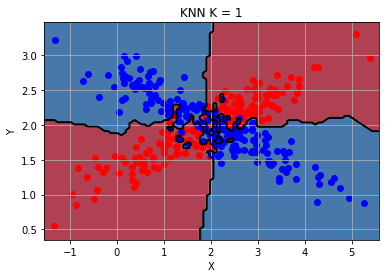

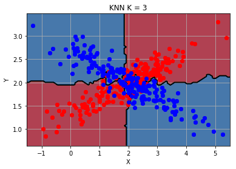

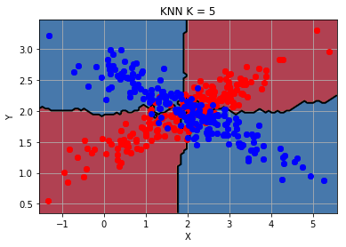

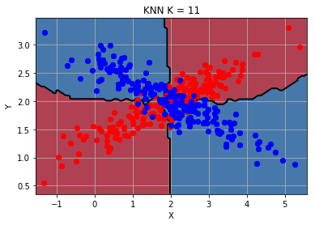

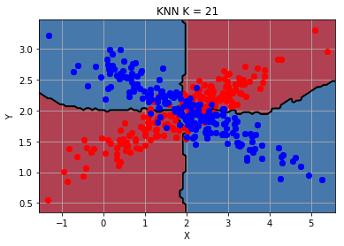

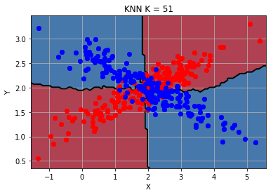

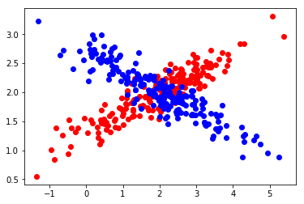

```python
dataset = Datos("ConjuntosDatos/example1.data")
k_values = [1, 3, 5, 11, 21, 51]

for k in k_values:
    print("-------------------------------------------------------------------")
    print("K = ", k)
    estrategia = ValidacionCruzada()
    knn = ClasificadorVecinosProximos(k, normaliza=True)
    val = knn.validacion(estrategia,dataset,knn)

    print("\nDatos normalizados:")
    print("Promedio del error = ", round(np.array(val).mean(),4), "\tDesviación típica = ", round(np.array(val).std(),4))
    ii=estrategia.particiones[-1].indicesTrain

    plotModel(dataset.datos[ii,0],dataset.datos[ii,1],dataset.datos[ii,-1]!=0,knn,"KNN K = " +str(k),dataset.diccionarios)


    plt.figure()
    plt.plot(dataset.datos[dataset.datos[:,-1]==0,0], dataset.datos[dataset.datos[:,-1]==0,1],'ro')
    plt.plot(dataset.datos[dataset.datos[:,-1]==1,0], dataset.datos[dataset.datos[:,-1]==1,1],'bo')
```

### Representación de los resultados de ejecución del ejemplo 2

```
-------------------------------------------------------------------
K =  1

Datos normalizados:
Promedio del error =  0.0 	Desviación típica =  0.0
-------------------------------------------------------------------
K =  3

Datos normalizados:
Promedio del error =  0.0 	Desviación típica =  0.0
-------------------------------------------------------------------
K =  5

Datos normalizados:
Promedio del error =  0.0 	Desviación típica =  0.0
-------------------------------------------------------------------
K =  11

Datos normalizados:
Promedio del error =  0.0 	Desviación típica =  0.0
-------------------------------------------------------------------
K =  21

Datos normalizados:
Promedio del error =  0.0 	Desviación típica =  0.0
-------------------------------------------------------------------
K =  51

Datos normalizados:
Promedio del error =  0.0 	Desviación típica =  0.0
```

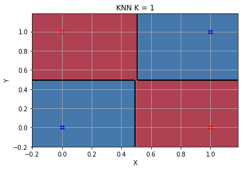

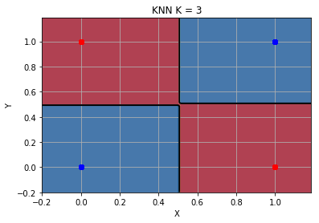

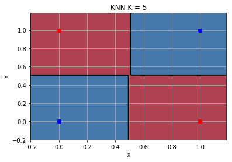

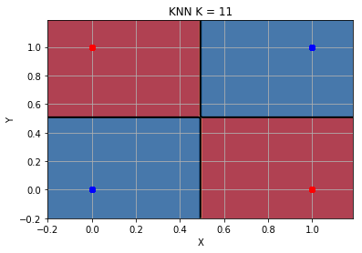

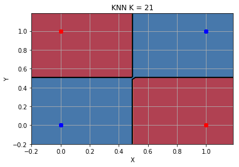

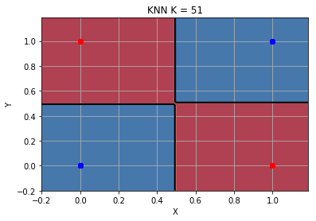

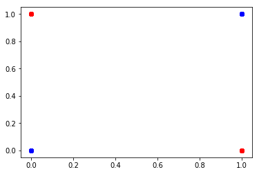

```python
dataset = Datos("ConjuntosDatos/example2.data")
k_values = [1, 3, 5, 11, 21, 51]

for k in k_values:
    print("-------------------------------------------------------------------")
    print("K = ", k)
    estrategia = ValidacionCruzada()
    knn = ClasificadorVecinosProximos(k, normaliza=True)
    val = knn.validacion(estrategia,dataset,knn)

    print("\nDatos normalizados:")
    print("Promedio del error = ", round(np.array(val).mean(),4), "\tDesviación típica = ", round(np.array(val).std(),4))
    ii=estrategia.particiones[-1].indicesTrain

    plotModel(dataset.datos[ii,0],dataset.datos[ii,1],dataset.datos[ii,-1]!=0,knn,"KNN K = " +str(k),dataset.diccionarios)


    plt.figure()
    plt.plot(dataset.datos[dataset.datos[:,-1]==0,0], dataset.datos[dataset.datos[:,-1]==0,1],'ro')
    plt.plot(dataset.datos[dataset.datos[:,-1]==1,0], dataset.datos[dataset.datos[:,-1]==1,1],'bo')
```

### Representación de los resultados de ejecución del ejemplo 3

```
-------------------------------------------------------------------
K =  1

Datos normalizados:
Promedio del error =  0.0225 	Desviación típica =  0.0707
-------------------------------------------------------------------
K =  3

Datos normalizados:
Promedio del error =  0.035 	Desviación típica =  0.0882
-------------------------------------------------------------------
K =  5

Datos normalizados:
Promedio del error =  0.0325 	Desviación típica =  0.0738
-------------------------------------------------------------------
K =  11

Datos normalizados:
Promedio del error =  0.0175 	Desviación típica =  0.0648
-------------------------------------------------------------------
K =  21

Datos normalizados:
Promedio del error =  0.03 	Desviación típica =  0.0781
-------------------------------------------------------------------
K =  51

Datos normalizados:
Promedio del error =  0.0175 	Desviación típica =  0.0565
```

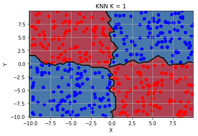

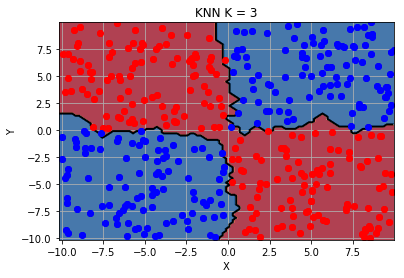

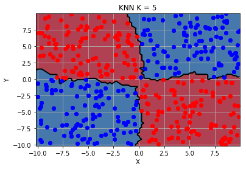

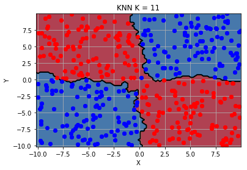

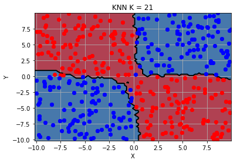

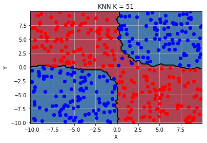

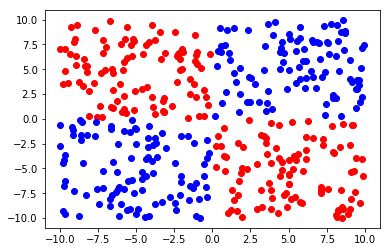

```python
dataset = Datos("ConjuntosDatos/example3.data")
k_values = [1, 3, 5, 11, 21, 51]

for k in k_values:
    print("-------------------------------------------------------------------")
    print("K = ", k)
    estrategia = ValidacionCruzada()
    knn = ClasificadorVecinosProximos(k, normaliza=True)
    val = knn.validacion(estrategia,dataset,knn)

    print("\nDatos normalizados:")
    print("Promedio del error = ", round(np.array(val).mean(),4), "\tDesviación típica = ", round(np.array(val).std(),4))
    ii=estrategia.particiones[-1].indicesTrain

    plotModel(dataset.datos[ii,0],dataset.datos[ii,1],dataset.datos[ii,-1]!=0,knn,"KNN K = " +str(k),dataset.diccionarios)


    plt.figure()
    plt.plot(dataset.datos[dataset.datos[:,-1]==0,0], dataset.datos[dataset.datos[:,-1]==0,1],'ro')
    plt.plot(dataset.datos[dataset.datos[:,-1]==1,0], dataset.datos[dataset.datos[:,-1]==1,1],'bo')
```

### Representación de los resultados de ejecución del ejemplo 4

```
-------------------------------------------------------------------
K =  1

Datos normalizados:
Promedio del error =  0.05 	Desviación típica =  0.1072
-------------------------------------------------------------------
K =  3

Datos normalizados:
Promedio del error =  0.08 	Desviación típica =  0.1166
-------------------------------------------------------------------
K =  5

Datos normalizados:
Promedio del error =  0.1 	Desviación típica =  0.1732
-------------------------------------------------------------------
K =  11

Datos normalizados:
Promedio del error =  0.2 	Desviación típica =  0.1897
-------------------------------------------------------------------
K =  21

Datos normalizados:
Promedio del error =  0.34 	Desviación típica =  0.18
-------------------------------------------------------------------
K =  51

Datos normalizados:
Promedio del error =  0.61 	Desviación típica =  0.2047
```

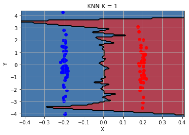

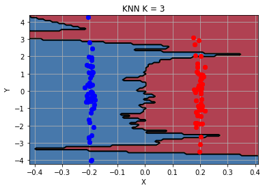

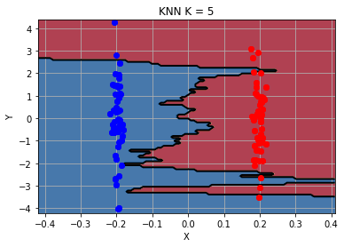

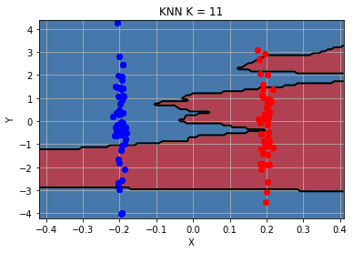

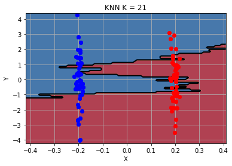

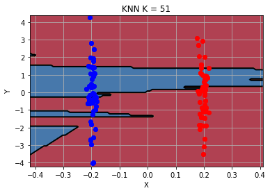

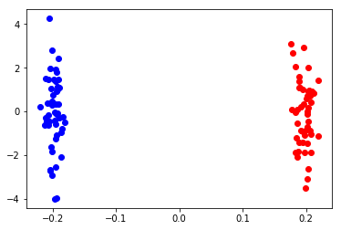

```python
dataset = Datos("ConjuntosDatos/example4.data")
k_values = [1, 3, 5, 11, 21, 51]

for k in k_values:
    print("-------------------------------------------------------------------")
    print("K = ", k)
    estrategia = ValidacionCruzada()
    knn = ClasificadorVecinosProximos(k, normaliza=True)
    val = knn.validacion(estrategia,dataset,knn)

    print("\nDatos normalizados:")
    print("Promedio del error = ", round(np.array(val).mean(),4), "\tDesviación típica = ", round(np.array(val).std(),4))
    ii=estrategia.particiones[-1].indicesTrain

    plotModel(dataset.datos[ii,0],dataset.datos[ii,1],dataset.datos[ii,-1]!=0,knn,"KNN K = " +str(k),dataset.diccionarios)


    plt.figure()
    plt.plot(dataset.datos[dataset.datos[:,-1]==0,0], dataset.datos[dataset.datos[:,-1]==0,1],'ro')
    plt.plot(dataset.datos[dataset.datos[:,-1]==1,0], dataset.datos[dataset.datos[:,-1]==1,1],'bo')
```